# examples_0406_B

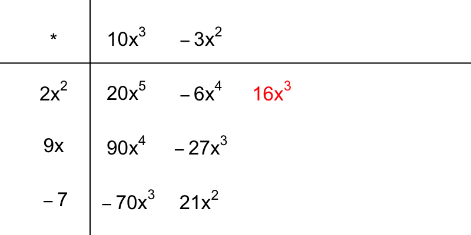

Now we know the column label.

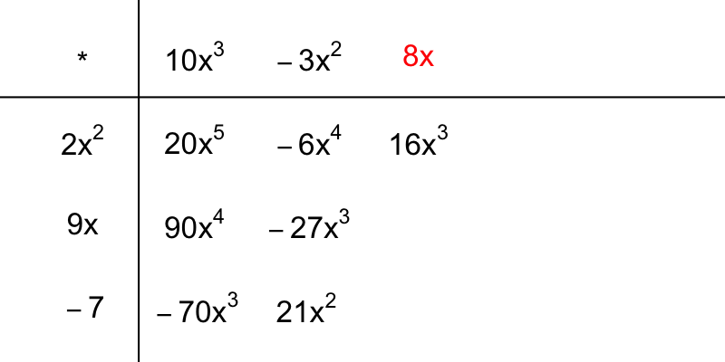

And the rest of that column.

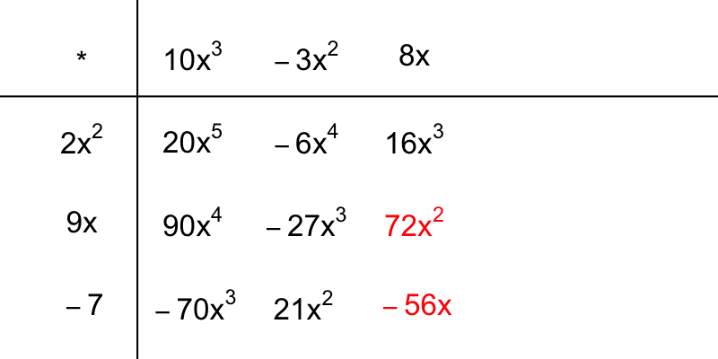

The dividend's quadratic term is $81x^2$. The product's terms need to combine to give that term. So far there is $21x^2$ and $72x^2$, which combine to give $93x^2$, so we need the next term to be $-12x^2$.

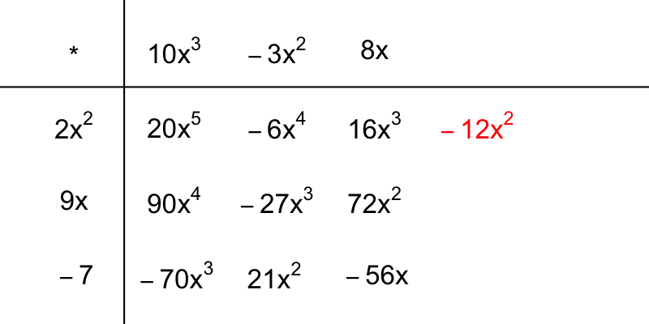

We know the column label.

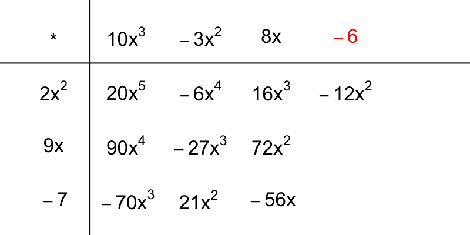

We know the rest of the column.

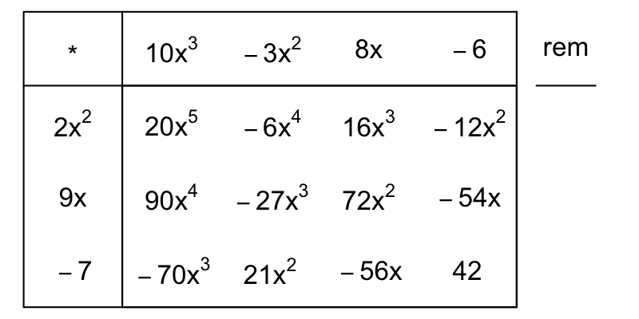

Now, the dividend's last two terms are $-105x$ and $38$. We set the remainder's terms to match.

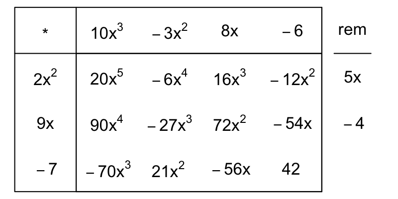

Thus, we know:

$${5}x-{4}+({2}x^{2}+{9}x-{7})\cdot({10}x^{3}-{3}x^{2}+{8}x-{6})~\equiv~
{20}x^{5}+{84}x^{4}-{81}x^{3}+{81}x^{2}-{105}x+{38}$$

And, so if we divide both sides by ${2}x^{2}+{9}x-{7}$, and switch sides, we get our answer:

$$\frac{{20}x^{5}+{84}x^{4}-{81}x^{3}+{81}x^{2}-{105}x+{38}}{{2}x^{2}+{9}x-{7}}~\equiv~{10}x^{3}-{3}x^{2}+{8}x-{6}+\frac{{5}x-{4}}{{2}x^{2}+{9}x-{7}}$$

And, so:

$$p=10$$
$$q=-3$$
$$r=8$$
$$s=-6$$
$$m=5$$
$$n=-4$$

Use polynomial division to express $\frac{{54}x^{5}-{60}x^{4}-{95}x^{3}-{77}x^{2}+{3}x+{22}}{{6}x^{2}-{10}x-{7}}$ in the form below:

$$px^3+qx^2+rx+s+\frac{mx+n}{{6}x^{2}-{10}x-{7}}$$

Find the coefficients:

- $p=$
- $q=$
- $r=$
- $s=$
- $m=$
- $n=$

The dividend is ${54}x^{5}-{60}x^{4}-{95}x^{3}-{77}x^{2}+{3}x+{22}$, and the divisor is ${6}x^{2}-{10}x-{7}$.

You could use polynomial long division. I will show how to use the box method. Keep in mind the box represents multiplication. Are unknown result will show as the column labels. The dividend will show, broken into extra terms, as the product of the divisor and another polynomial.

Place the divisor as the row labels, and put the highest-degree term in the top left entry.

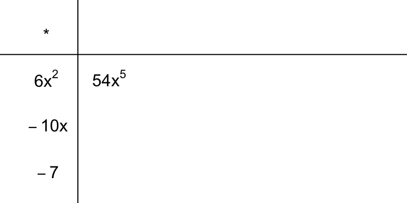

Now, we know what the first column's label needs to be because $(6x^2)\cdot(9x^3)\equiv 54x^5$.

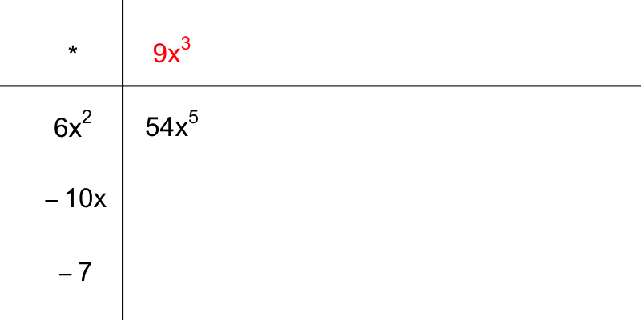

The rest of the column can be determined with multiplication.

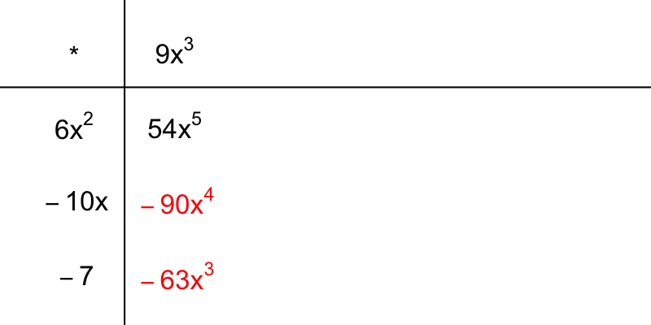

The dividend's 4th-degree term is $-60x^4$. Currently, the product has $-90x^4$, so the next needed term is $30x^4$.

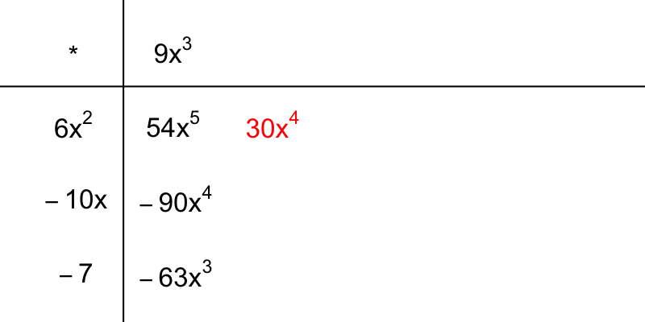

Now we know the column label.

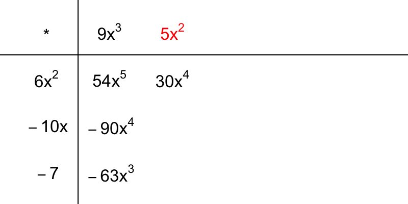

And the rest of the column, by using multiplication.

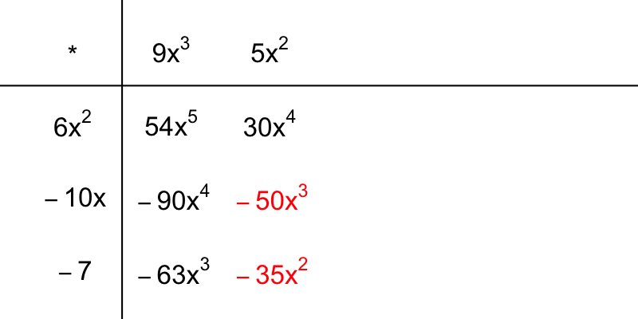

Notice, the table's entries contain two cubic terms so far, $-63x^3$ and $-50x^3$, which combine to give $-113x^3$. The dividend has $-95x^3$ as its cubic term, so the next term in the entries needs to be $18x^3$. Notice that the sum of $-63x^3$ and $-50x^3$ and $18x^3$ equals the cubic term of the dividend.

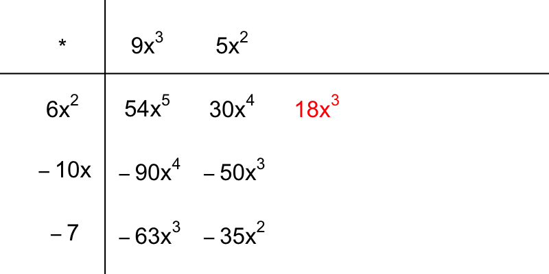

Now we know the column label.

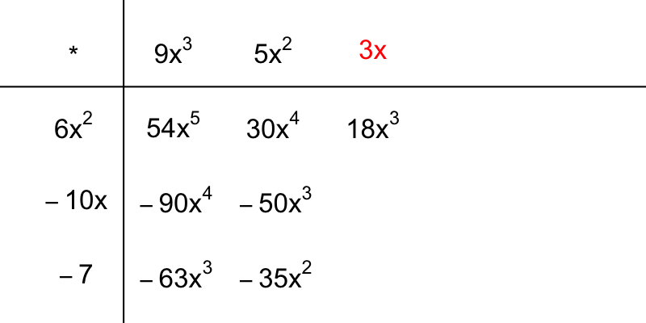

And the rest of that column.

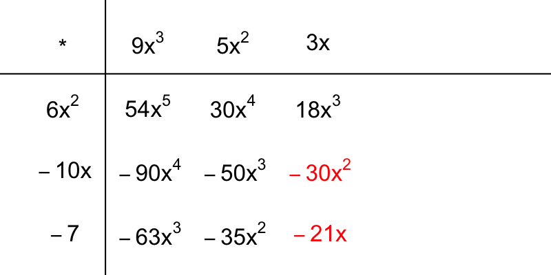

The dividend's quadratic term is $-77x^2$. The product's terms need to combine to give that term. So far there is $-35x^2$ and $-30x^2$, which combine to give $-65x^2$, so we need the next term to be $-12x^2$.

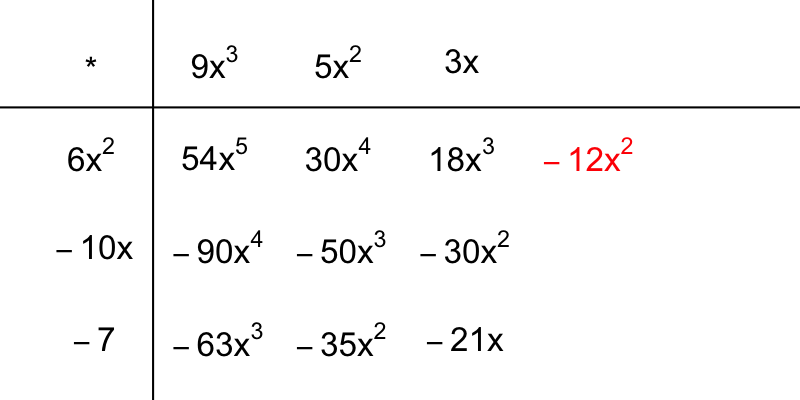

We know the column label.

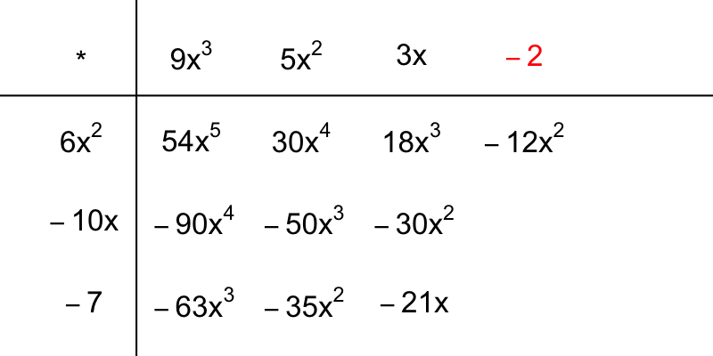

We know the rest of the column.

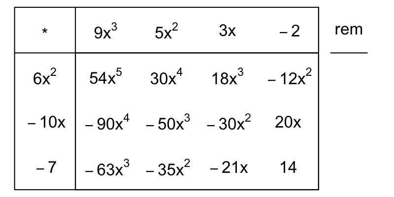

Now, the dividend's last two terms are $3x$ and $22$. We set the remainder's terms to match.

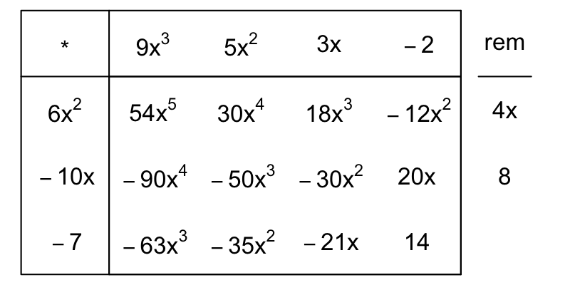

Thus, we know:

$${4}x+{8}+({6}x^{2}-{10}x-{7})\cdot({9}x^{3}+{5}x^{2}+{3}x-{2})~\equiv~
{54}x^{5}-{60}x^{4}-{95}x^{3}-{77}x^{2}+{3}x+{22}$$

And, so if we divide both sides by ${6}x^{2}-{10}x-{7}$, and switch sides, we get our answer:

$$\frac{{54}x^{5}-{60}x^{4}-{95}x^{3}-{77}x^{2}+{3}x+{22}}{{6}x^{2}-{10}x-{7}}~\equiv~{9}x^{3}+{5}x^{2}+{3}x-{2}+\frac{{4}x+{8}}{{6}x^{2}-{10}x-{7}}$$

And, so:

$$p=9$$
$$q=5$$
$$r=3$$
$$s=-2$$
$$m=4$$
$$n=8$$

Use polynomial division to express $\frac{{16}x^{5}+{52}x^{4}+{86}x^{3}+{98}x^{2}+{34}x-{33}}{{8}x^{2}+{10}x-{5}}$ in the form below:

$$px^3+qx^2+rx+s+\frac{mx+n}{{8}x^{2}+{10}x-{5}}$$

Find the coefficients:

- $p=$
- $q=$
- $r=$
- $s=$
- $m=$
- $n=$

The dividend is ${16}x^{5}+{52}x^{4}+{86}x^{3}+{98}x^{2}+{34}x-{33}$, and the divisor is ${8}x^{2}+{10}x-{5}$.

You could use polynomial long division. I will show how to use the box method. Keep in mind the box represents multiplication. Are unknown result will show as the column labels. The dividend will show, broken into extra terms, as the product of the divisor and another polynomial.

Place the divisor as the row labels, and put the highest-degree term in the top left entry.

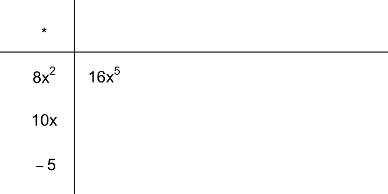

Now, we know what the first column's label needs to be because $(8x^2)\cdot(2x^3)\equiv 16x^5$.

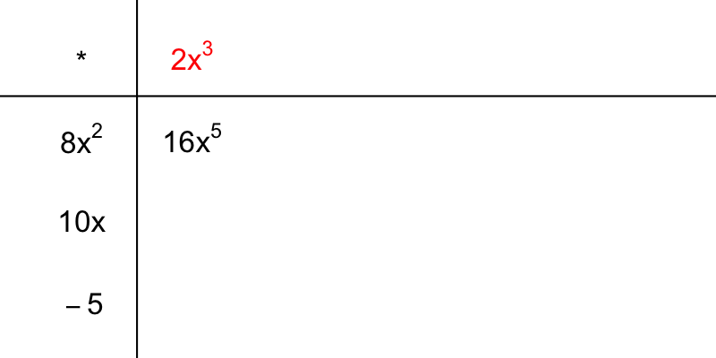

The rest of the column can be determined with multiplication.

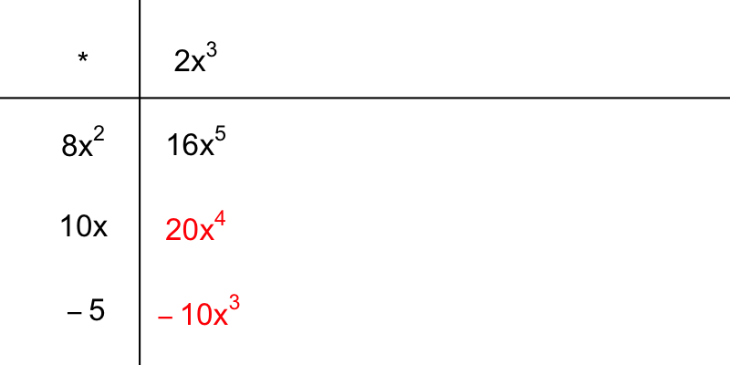

The dividend's 4th-degree term is $52x^4$. Currently, the product has $20x^4$, so the next needed term is $32x^4$.

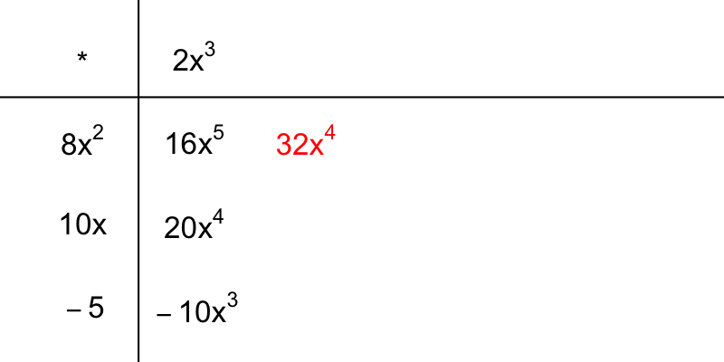

Now we know the column label.

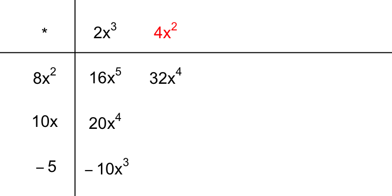

And the rest of the column, by using multiplication.

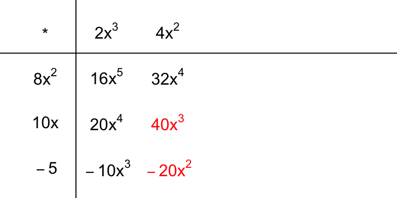

Notice, the table's entries contain two cubic terms so far, $-10x^3$ and $40x^3$, which combine to give $30x^3$. The dividend has $86x^3$ as its cubic term, so the next term in the entries needs to be $56x^3$. Notice that the sum of $-10x^3$ and $40x^3$ and $56x^3$ equals the cubic term of the dividend.

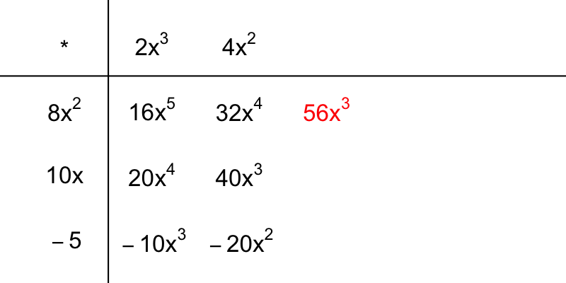

Now we know the column label.

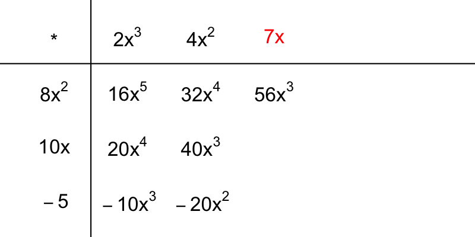

And the rest of that column.

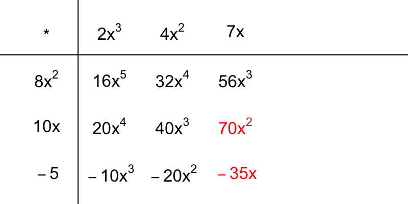

The dividend's quadratic term is $98x^2$. The product's terms need to combine to give that term. So far there is $-20x^2$ and $70x^2$, which combine to give $50x^2$, so we need the next term to be $48x^2$.

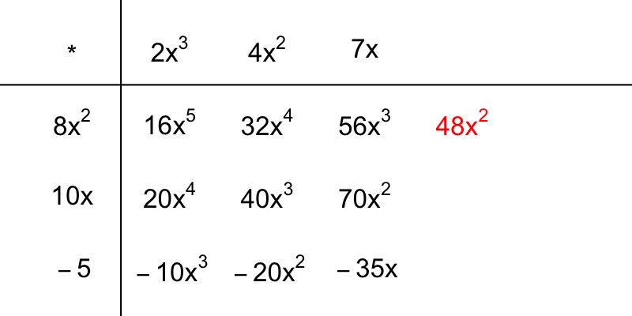

We know the column label.

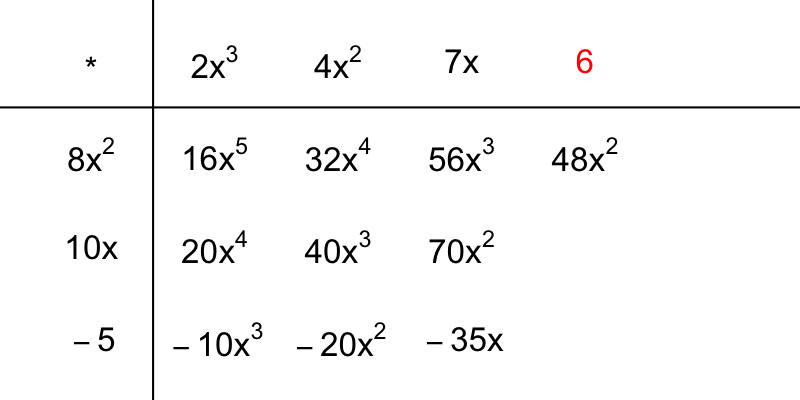

We know the rest of the column.

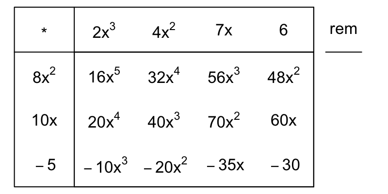

Now, the dividend's last two terms are $34x$ and $-33$. We set the remainder's terms to match.

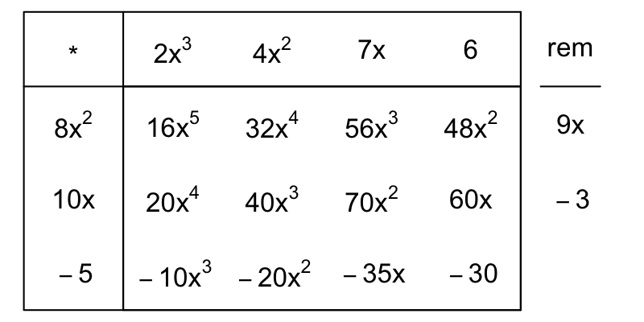

Thus, we know:

$${9}x-{3}+({8}x^{2}+{10}x-{5})\cdot({2}x^{3}+{4}x^{2}+{7}x+{6})~\equiv~
{16}x^{5}+{52}x^{4}+{86}x^{3}+{98}x^{2}+{34}x-{33}$$

And, so if we divide both sides by ${8}x^{2}+{10}x-{5}$, and switch sides, we get our answer:

$$\frac{{16}x^{5}+{52}x^{4}+{86}x^{3}+{98}x^{2}+{34}x-{33}}{{8}x^{2}+{10}x-{5}}~\equiv~{2}x^{3}+{4}x^{2}+{7}x+{6}+\frac{{9}x-{3}}{{8}x^{2}+{10}x-{5}}$$

And, so:

$$p=2$$
$$q=4$$
$$r=7$$
$$s=6$$
$$m=9$$
$$n=-3$$

Use polynomial division to express $\frac{{42}x^{5}+{44}x^{4}-{109}x^{3}-{82}x^{2}-{38}x+{86}}{{6}x^{2}+{8}x-{9}}$ in the form below:

$$px^3+qx^2+rx+s+\frac{mx+n}{{6}x^{2}+{8}x-{9}}$$

Find the coefficients:

- $p=$
- $q=$
- $r=$
- $s=$
- $m=$
- $n=$

The dividend is ${42}x^{5}+{44}x^{4}-{109}x^{3}-{82}x^{2}-{38}x+{86}$, and the divisor is ${6}x^{2}+{8}x-{9}$.

You could use polynomial long division. I will show how to use the box method. Keep in mind the box represents multiplication. Are unknown result will show as the column labels. The dividend will show, broken into extra terms, as the product of the divisor and another polynomial.

Place the divisor as the row labels, and put the highest-degree term in the top left entry.

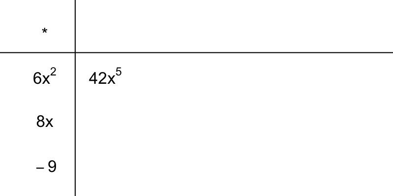

Now, we know what the first column's label needs to be because $(6x^2)\cdot(7x^3)\equiv 42x^5$.

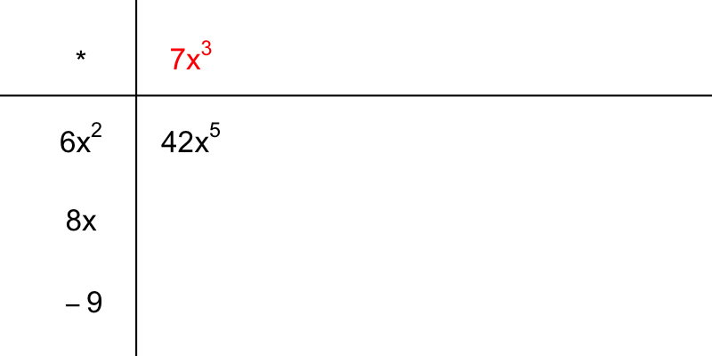

The rest of the column can be determined with multiplication.

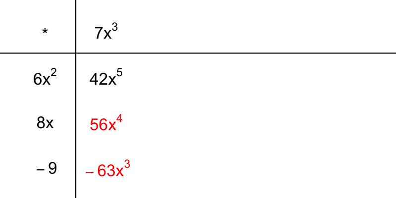

The dividend's 4th-degree term is $44x^4$. Currently, the product has $56x^4$, so the next needed term is $-12x^4$.

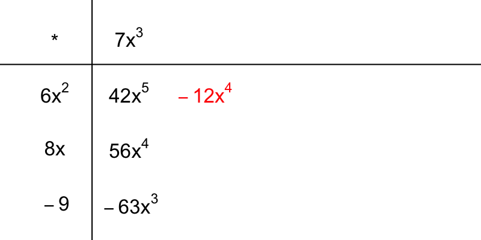

Now we know the column label.

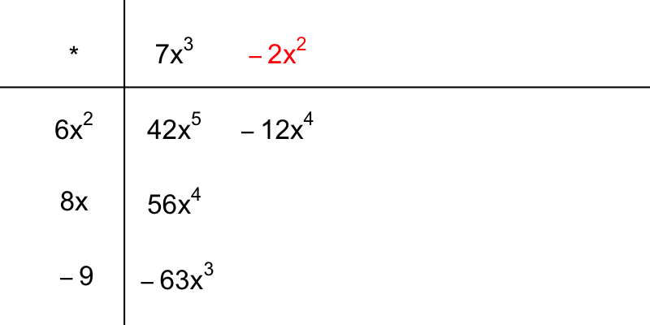

And the rest of the column, by using multiplication.

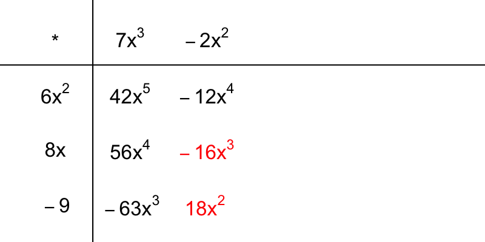

Notice, the table's entries contain two cubic terms so far, $-63x^3$ and $-16x^3$, which combine to give $-79x^3$. The dividend has $-109x^3$ as its cubic term, so the next term in the entries needs to be $-30x^3$. Notice that the sum of $-63x^3$ and $-16x^3$ and $-30x^3$ equals the cubic term of the dividend.

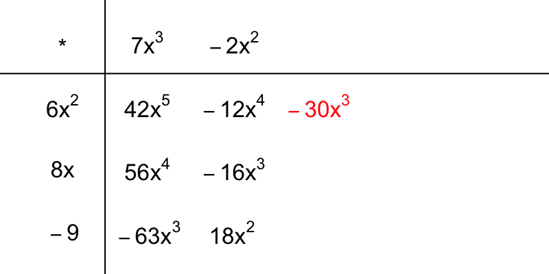

Now we know the column label.

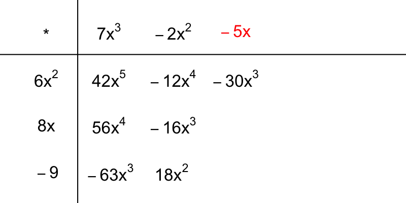

And the rest of that column.

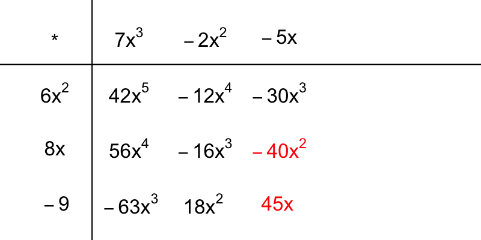

The dividend's quadratic term is $-82x^2$. The product's terms need to combine to give that term. So far there is $18x^2$ and $-40x^2$, which combine to give $-22x^2$, so we need the next term to be $-60x^2$.

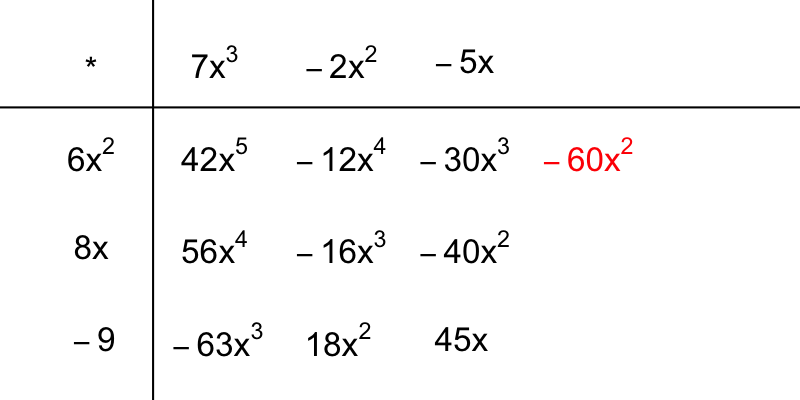

We know the column label.

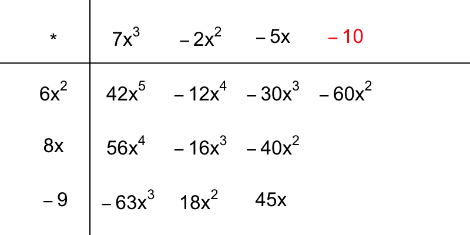

We know the rest of the column.

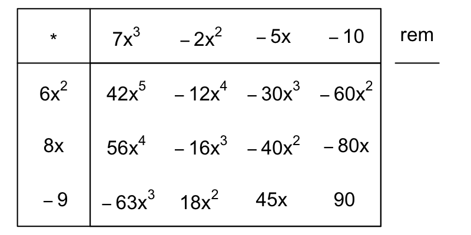

Now, the dividend's last two terms are $-38x$ and $86$. We set the remainder's terms to match.

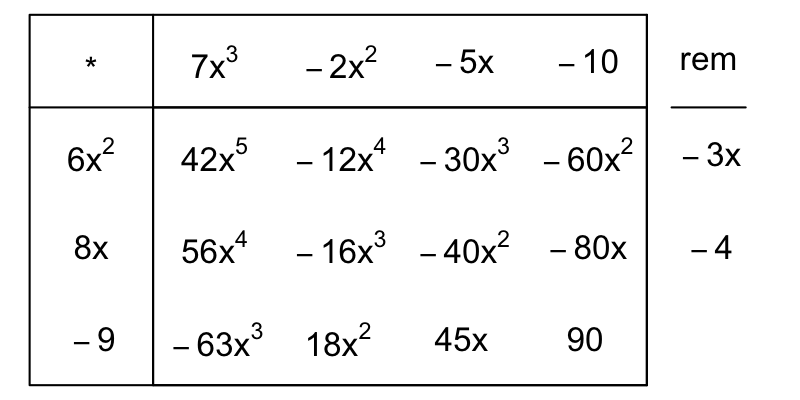

Thus, we know:

$${-3}x-{4}+({6}x^{2}+{8}x-{9})\cdot({7}x^{3}-{2}x^{2}-{5}x-{10})~\equiv~
{42}x^{5}+{44}x^{4}-{109}x^{3}-{82}x^{2}-{38}x+{86}$$

And, so if we divide both sides by ${6}x^{2}+{8}x-{9}$, and switch sides, we get our answer:

$$\frac{{42}x^{5}+{44}x^{4}-{109}x^{3}-{82}x^{2}-{38}x+{86}}{{6}x^{2}+{8}x-{9}}~\equiv~{7}x^{3}-{2}x^{2}-{5}x-{10}+\frac{{-3}x-{4}}{{6}x^{2}+{8}x-{9}}$$

And, so:

$$p=7$$
$$q=-2$$
$$r=-5$$
$$s=-10$$
$$m=-3$$
$$n=-4$$

Use polynomial division to express $\frac{{35}x^{5}-{26}x^{4}+{27}x^{3}-{96}x^{2}+{98}x-{39}}{{7}x^{2}-{8}x+{3}}$ in the form below:

$$px^3+qx^2+rx+s+\frac{mx+n}{{7}x^{2}-{8}x+{3}}$$

Find the coefficients:

- $p=$
- $q=$
- $r=$
- $s=$
- $m=$
- $n=$

The dividend is ${35}x^{5}-{26}x^{4}+{27}x^{3}-{96}x^{2}+{98}x-{39}$, and the divisor is ${7}x^{2}-{8}x+{3}$.

You could use polynomial long division. I will show how to use the box method. Keep in mind the box represents multiplication. Are unknown result will show as the column labels. The dividend will show, broken into extra terms, as the product of the divisor and another polynomial.

Place the divisor as the row labels, and put the highest-degree term in the top left entry.

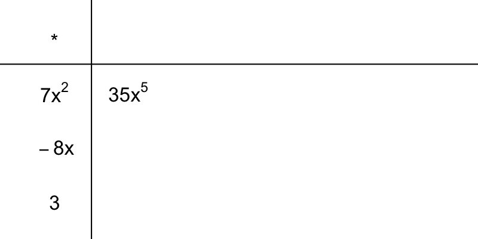

Now, we know what the first column's label needs to be because $(7x^2)\cdot(5x^3)\equiv 35x^5$.

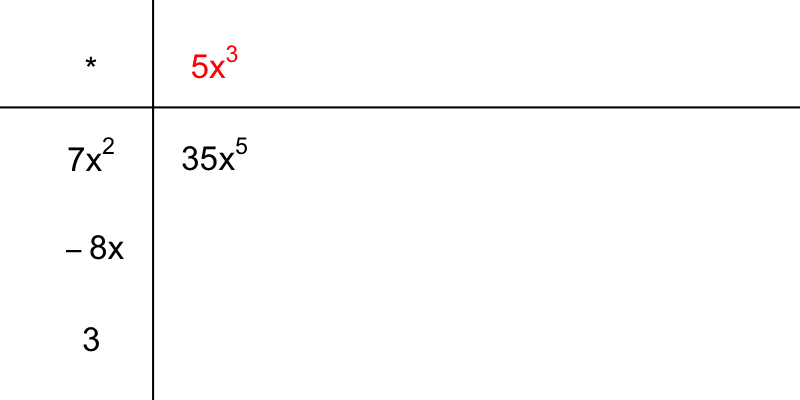

The rest of the column can be determined with multiplication.

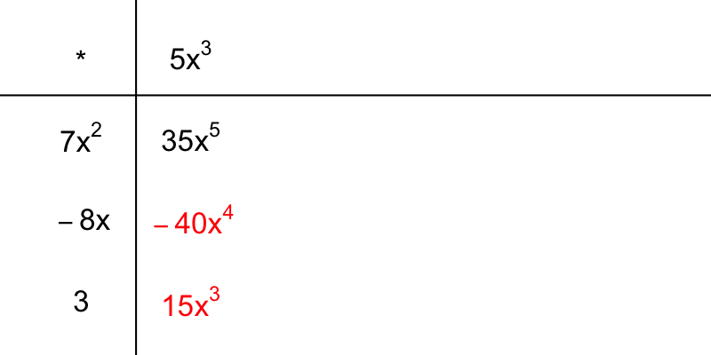

The dividend's 4th-degree term is $-26x^4$. Currently, the product has $-40x^4$, so the next needed term is $14x^4$.

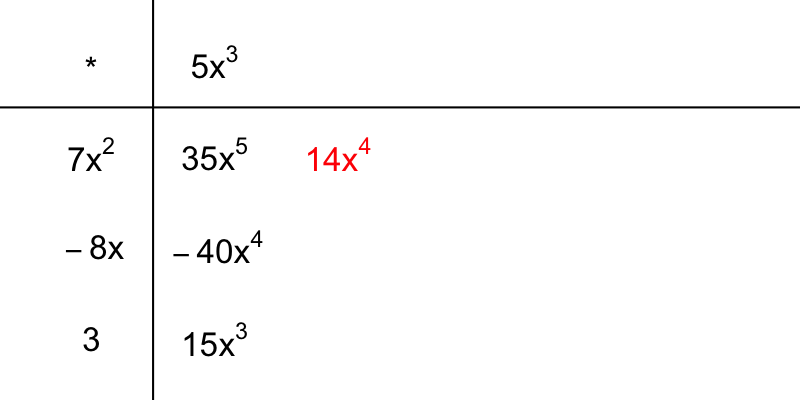

Now we know the column label.

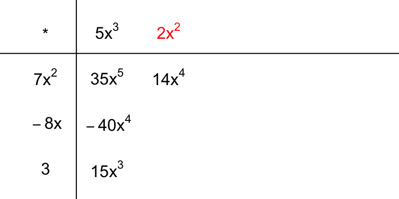

And the rest of the column, by using multiplication.

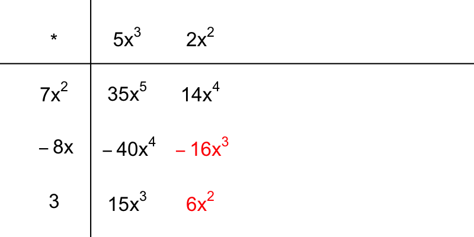

Notice, the table's entries contain two cubic terms so far, $15x^3$ and $-16x^3$, which combine to give $-1x^3$. The dividend has $27x^3$ as its cubic term, so the next term in the entries needs to be $28x^3$. Notice that the sum of $15x^3$ and $-16x^3$ and $28x^3$ equals the cubic term of the dividend.